# Risk Factor Analysis

## Outcome Variable

**Outcome Variable:** ever_co

## Predictor Variables

**Intervention Variable:** impfloor

**Adjustment Set:**

unadjusted

## Stratifying Variables

The analysis was stratified on these variable(s):

- agecat
- studyid
- country

## Data Summary

| agecat | studyid | country | impfloor | ever_co | n_cell | n | outcome_variable |
| --- | --- | --- | --- | --- | --- | --- | --- |
| 0-24 months | ki0047075b-MAL-ED | BANGLADESH | 1 | 0 | 189 | 242 | ever_co |
| 0-24 months | ki0047075b-MAL-ED | BANGLADESH | 1 | 1 | 34 | 242 | ever_co |
| 0-24 months | ki0047075b-MAL-ED | BANGLADESH | 0 | 0 | 14 | 242 | ever_co |
| 0-24 months | ki0047075b-MAL-ED | BANGLADESH | 0 | 1 | 5 | 242 | ever_co |
| 0-24 months | ki0047075b-MAL-ED | BRAZIL | 1 | 0 | 205 | 210 | ever_co |
| 0-24 months | ki0047075b-MAL-ED | BRAZIL | 1 | 1 | 3 | 210 | ever_co |
| 0-24 months | ki0047075b-MAL-ED | BRAZIL | 0 | 0 | 2 | 210 | ever_co |
| 0-24 months | ki0047075b-MAL-ED | BRAZIL | 0 | 1 | 0 | 210 | ever_co |
| 0-24 months | ki0047075b-MAL-ED | INDIA | 1 | 0 | 173 | 235 | ever_co |
| 0-24 months | ki0047075b-MAL-ED | INDIA | 1 | 1 | 47 | 235 | ever_co |
| 0-24 months | ki0047075b-MAL-ED | INDIA | 0 | 0 | 9 | 235 | ever_co |
| 0-24 months | ki0047075b-MAL-ED | INDIA | 0 | 1 | 6 | 235 | ever_co |
| 0-24 months | ki0047075b-MAL-ED | NEPAL | 1 | 0 | 93 | 229 | ever_co |
| 0-24 months | ki0047075b-MAL-ED | NEPAL | 1 | 1 | 10 | 229 | ever_co |
| 0-24 months | ki0047075b-MAL-ED | NEPAL | 0 | 0 | 116 | 229 | ever_co |
| 0-24 months | ki0047075b-MAL-ED | NEPAL | 0 | 1 | 10 | 229 | ever_co |
| 0-24 months | ki0047075b-MAL-ED | PERU | 1 | 0 | 55 | 272 | ever_co |
| 0-24 months | ki0047075b-MAL-ED | PERU | 1 | 1 | 4 | 272 | ever_co |
| 0-24 months | ki0047075b-MAL-ED | PERU | 0 | 0 | 206 | 272 | ever_co |
| 0-24 months | ki0047075b-MAL-ED | PERU | 0 | 1 | 7 | 272 | ever_co |
| 0-24 months | ki0047075b-MAL-ED | SOUTH AFRICA | 1 | 0 | 214 | 257 | ever_co |
| 0-24 months | ki0047075b-MAL-ED | SOUTH AFRICA | 1 | 1 | 22 | 257 | ever_co |
| 0-24 months | ki0047075b-MAL-ED | SOUTH AFRICA | 0 | 0 | 21 | 257 | ever_co |
| 0-24 months | ki0047075b-MAL-ED | SOUTH AFRICA | 0 | 1 | 0 | 257 | ever_co |
| 0-24 months | ki0047075b-MAL-ED | TANZANIA, UNITED REPUBLIC OF | 1 | 0 | 14 | 248 | ever_co |
| 0-24 months | ki0047075b-MAL-ED | TANZANIA, UNITED REPUBLIC OF | 1 | 1 | 0 | 248 | ever_co |
| 0-24 months | ki0047075b-MAL-ED | TANZANIA, UNITED REPUBLIC OF | 0 | 0 | 211 | 248 | ever_co |
| 0-24 months | ki0047075b-MAL-ED | TANZANIA, UNITED REPUBLIC OF | 0 | 1 | 23 | 248 | ever_co |
| 0-24 months | ki1000108-CMC-V-BCS-2002 | INDIA | 1 | 0 | 198 | 261 | ever_co |
| 0-24 months | ki1000108-CMC-V-BCS-2002 | INDIA | 1 | 1 | 63 | 261 | ever_co |

[output cut: 162 more lines]

The following strata were considered:

- agecat: 0-24 months, studyid: ki0047075b-MAL-ED, country: BANGLADESH
- agecat: 0-24 months, studyid: ki0047075b-MAL-ED, country: BRAZIL
- agecat: 0-24 months, studyid: ki0047075b-MAL-ED, country: INDIA
- agecat: 0-24 months, studyid: ki0047075b-MAL-ED, country: NEPAL
- agecat: 0-24 months, studyid: ki0047075b-MAL-ED, country: PERU
- agecat: 0-24 months, studyid: ki0047075b-MAL-ED, country: SOUTH AFRICA
- agecat: 0-24 months, studyid: ki0047075b-MAL-ED, country: TANZANIA, UNITED REPUBLIC OF
- agecat: 0-24 months, studyid: ki1000108-CMC-V-BCS-2002, country: INDIA
- agecat: 0-24 months, studyid: ki1000108-IRC, country: INDIA
- agecat: 0-24 months, studyid: ki1017093-NIH-Birth, country: BANGLADESH
- agecat: 0-24 months, studyid: ki1017093b-PROVIDE, country: BANGLADESH
- agecat: 0-24 months, studyid: ki1017093c-NIH-Crypto, country: BANGLADESH
- agecat: 0-24 months, studyid: ki1113344-GMS-Nepal, country: NEPAL
- agecat: 0-24 months, studyid: ki1114097-CONTENT, country: PERU
- agecat: 0-24 months, studyid: kiGH5241-JiVitA-3, country: BANGLADESH
- agecat: 0-24 months, studyid: kiGH5241-JiVitA-4, country: BANGLADESH
- agecat: 0-6 months, studyid: ki0047075b-MAL-ED, country: BANGLADESH
- agecat: 0-6 months, studyid: ki0047075b-MAL-ED, country: BRAZIL
- agecat: 0-6 months, studyid: ki0047075b-MAL-ED, country: INDIA
- agecat: 0-6 months, studyid: ki0047075b-MAL-ED, country: NEPAL
- agecat: 0-6 months, studyid: ki0047075b-MAL-ED, country: PERU
- agecat: 0-6 months, studyid: ki0047075b-MAL-ED, country: SOUTH AFRICA
- agecat: 0-6 months, studyid: ki0047075b-MAL-ED, country: TANZANIA, UNITED REPUBLIC OF
- agecat: 0-6 months, studyid: ki1000108-CMC-V-BCS-2002, country: INDIA
- agecat: 0-6 months, studyid: ki1000108-IRC, country: INDIA
- agecat: 0-6 months, studyid: ki1017093-NIH-Birth, country: BANGLADESH
- agecat: 0-6 months, studyid: ki1017093b-PROVIDE, country: BANGLADESH
- agecat: 0-6 months, studyid: ki1017093c-NIH-Crypto, country: BANGLADESH
- agecat: 0-6 months, studyid: ki1113344-GMS-Nepal, country: NEPAL
- agecat: 0-6 months, studyid: ki1114097-CONTENT, country: PERU
- agecat: 0-6 months, studyid: kiGH5241-JiVitA-3, country: BANGLADESH
- agecat: 0-6 months, studyid: kiGH5241-JiVitA-4, country: BANGLADESH
- agecat: 6-24 months, studyid: ki0047075b-MAL-ED, country: BANGLADESH
- agecat: 6-24 months, studyid: ki0047075b-MAL-ED, country: BRAZIL
- agecat: 6-24 months, studyid: ki0047075b-MAL-ED, country: INDIA
- agecat: 6-24 months, studyid: ki0047075b-MAL-ED, country: NEPAL
- agecat: 6-24 months, studyid: ki0047075b-MAL-ED, country: PERU
- agecat: 6-24 months, studyid: ki0047075b-MAL-ED, country: SOUTH AFRICA
- agecat: 6-24 months, studyid: ki0047075b-MAL-ED, country: TANZANIA, UNITED REPUBLIC OF
- agecat: 6-24 months, studyid: ki1000108-CMC-V-BCS-2002, country: INDIA
- agecat: 6-24 months, studyid: ki1000108-IRC, country: INDIA
- agecat: 6-24 months, studyid: ki1017093-NIH-Birth, country: BANGLADESH
- agecat: 6-24 months, studyid: ki1017093b-PROVIDE, country: BANGLADESH
- agecat: 6-24 months, studyid: ki1017093c-NIH-Crypto, country: BANGLADESH
- agecat: 6-24 months, studyid: ki1113344-GMS-Nepal, country: NEPAL
- agecat: 6-24 months, studyid: ki1114097-CONTENT, country: PERU
- agecat: 6-24 months, studyid: kiGH5241-JiVitA-3, country: BANGLADESH
- agecat: 6-24 months, studyid: kiGH5241-JiVitA-4, country: BANGLADESH

### Dropped Strata

Some strata were dropped due to rare outcomes:

- agecat: 0-24 months, studyid: ki0047075b-MAL-ED, country: BRAZIL
- agecat: 0-24 months, studyid: ki0047075b-MAL-ED, country: PERU
- agecat: 0-24 months, studyid: ki0047075b-MAL-ED, country: SOUTH AFRICA
- agecat: 0-24 months, studyid: ki0047075b-MAL-ED, country: TANZANIA, UNITED REPUBLIC OF
- agecat: 0-24 months, studyid: ki1000108-CMC-V-BCS-2002, country: INDIA
- agecat: 0-24 months, studyid: ki1000108-IRC, country: INDIA
- agecat: 0-24 months, studyid: ki1114097-CONTENT, country: PERU
- agecat: 0-6 months, studyid: ki0047075b-MAL-ED, country: BANGLADESH
- agecat: 0-6 months, studyid: ki0047075b-MAL-ED, country: BRAZIL
- agecat: 0-6 months, studyid: ki0047075b-MAL-ED, country: INDIA
- agecat: 0-6 months, studyid: ki0047075b-MAL-ED, country: NEPAL
- agecat: 0-6 months, studyid: ki0047075b-MAL-ED, country: PERU
- agecat: 0-6 months, studyid: ki0047075b-MAL-ED, country: SOUTH AFRICA
- agecat: 0-6 months, studyid: ki0047075b-MAL-ED, country: TANZANIA, UNITED REPUBLIC OF
- agecat: 0-6 months, studyid: ki1000108-CMC-V-BCS-2002, country: INDIA
- agecat: 0-6 months, studyid: ki1000108-IRC, country: INDIA
- agecat: 0-6 months, studyid: ki1017093c-NIH-Crypto, country: BANGLADESH
- agecat: 0-6 months, studyid: ki1114097-CONTENT, country: PERU
- agecat: 6-24 months, studyid: ki0047075b-MAL-ED, country: BANGLADESH
- agecat: 6-24 months, studyid: ki0047075b-MAL-ED, country: BRAZIL
- agecat: 6-24 months, studyid: ki0047075b-MAL-ED, country: PERU
- agecat: 6-24 months, studyid: ki0047075b-MAL-ED, country: SOUTH AFRICA
- agecat: 6-24 months, studyid: ki0047075b-MAL-ED, country: TANZANIA, UNITED REPUBLIC OF
- agecat: 6-24 months, studyid: ki1000108-CMC-V-BCS-2002, country: INDIA
- agecat: 6-24 months, studyid: ki1000108-IRC, country: INDIA
- agecat: 6-24 months, studyid: ki1114097-CONTENT, country: PERU

## Methods Detail

We’re interested in the causal parameters $E[Y_a]$ for all values of $a \in \mathcal{A}$. These parameters represent the mean outcome if, possibly contrary to fact, we intervened to set all units to have $A=a$. Under the randomization and positivity assumptions, these are identified by the statistical parameters $\psi_a=E_W[E_{Y|A,W}(Y|A=a,W)]$. In addition, we’re interested in the mean of $Y$, $E[Y]$ under no intervention (the observed mean). We will estimate these parameters by using SuperLearner to fit the relevant likelihood factors – $E_{Y|A,W}(Y|A=a,W)$ and $p(A=a|W)$, and then updating our likelihood fit using a joint TMLE.

For unadjusted analyses ($W=\{\}$), initial likelihoods were estimated using Lrnr_glm to estimate the simple $E(Y|A)$ and Lrnr_mean to estimate $p(A)$. For adjusted analyses, a small library containing Lrnr_glmnet, Lrnr_xgboost, and Lrnr_mean was used.

Having estimated these parameters, we will then use the delta method to estimate relative risks and attributable risks relative to a prespecified baseline level of $A$.

# Results Detail

## Results Plots

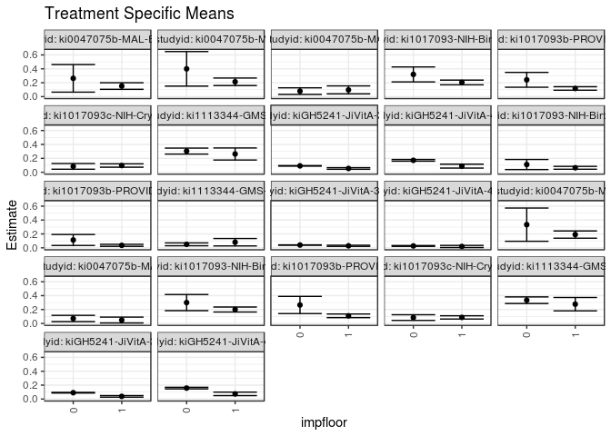

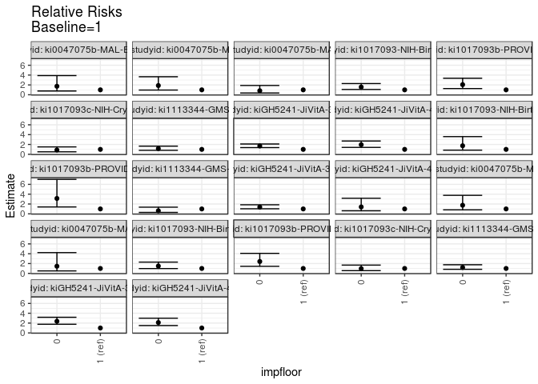

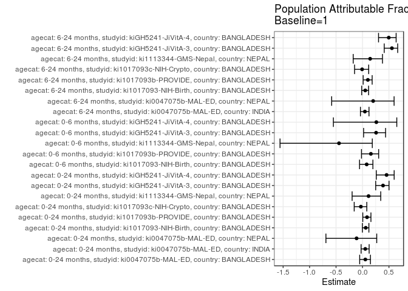

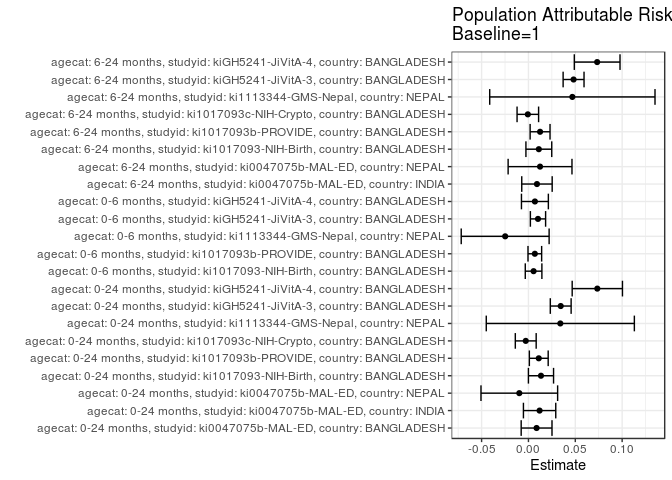

## Results Table

### Parameter: TSM

| agecat | studyid | country | intervention_level | baseline_level | estimate | ci_lower | ci_upper |
| --- | --- | --- | --- | --- | --- | --- | --- |
| 0-24 months | ki0047075b-MAL-ED | BANGLADESH | 1 | NA | 0.1524664 | 0.1051882 | 0.1997445 |
| 0-24 months | ki0047075b-MAL-ED | BANGLADESH | 0 | NA | 0.2631579 | 0.0647468 | 0.4615690 |
| 0-24 months | ki0047075b-MAL-ED | INDIA | 1 | NA | 0.2136364 | 0.1593598 | 0.2679129 |
| 0-24 months | ki0047075b-MAL-ED | INDIA | 0 | NA | 0.4000000 | 0.1515528 | 0.6484472 |
| 0-24 months | ki0047075b-MAL-ED | NEPAL | 1 | NA | 0.0970874 | 0.0397835 | 0.1543913 |
| 0-24 months | ki0047075b-MAL-ED | NEPAL | 0 | NA | 0.0793651 | 0.0320639 | 0.1266662 |
| 0-24 months | ki1017093-NIH-Birth | BANGLADESH | 1 | NA | 0.2040073 | 0.1702716 | 0.2377429 |
| 0-24 months | ki1017093-NIH-Birth | BANGLADESH | 0 | NA | 0.3194444 | 0.2116587 | 0.4272302 |
| 0-24 months | ki1017093b-PROVIDE | BANGLADESH | 1 | NA | 0.1175549 | 0.0925449 | 0.1425648 |
| 0-24 months | ki1017093b-PROVIDE | BANGLADESH | 0 | NA | 0.2419355 | 0.1352598 | 0.3486112 |
| 0-24 months | ki1017093c-NIH-Crypto | BANGLADESH | 1 | NA | 0.0965517 | 0.0724997 | 0.1206038 |
| 0-24 months | ki1017093c-NIH-Crypto | BANGLADESH | 0 | NA | 0.0842697 | 0.0434336 | 0.1251058 |
| 0-24 months | ki1113344-GMS-Nepal | NEPAL | 1 | NA | 0.2626263 | 0.1758604 | 0.3493921 |
| 0-24 months | ki1113344-GMS-Nepal | NEPAL | 0 | NA | 0.3043478 | 0.2611667 | 0.3475290 |
| 0-24 months | kiGH5241-JiVitA-3 | BANGLADESH | 1 | NA | 0.0542965 | 0.0428444 | 0.0657486 |
| 0-24 months | kiGH5241-JiVitA-3 | BANGLADESH | 0 | NA | 0.0916882 | 0.0876425 | 0.0957339 |
| 0-24 months | kiGH5241-JiVitA-4 | BANGLADESH | 1 | NA | 0.0879630 | 0.0597695 | 0.1161564 |
| 0-24 months | kiGH5241-JiVitA-4 | BANGLADESH | 0 | NA | 0.1714465 | 0.1593551 | 0.1835379 |
| 0-6 months | ki1017093-NIH-Birth | BANGLADESH | 1 | NA | 0.0639854 | 0.0434602 | 0.0845106 |
| 0-6 months | ki1017093-NIH-Birth | BANGLADESH | 0 | NA | 0.1111111 | 0.0384611 | 0.1837611 |
| 0-6 months | ki1017093b-PROVIDE | BANGLADESH | 1 | NA | 0.0360502 | 0.0215748 | 0.0505255 |
| 0-6 months | ki1017093b-PROVIDE | BANGLADESH | 0 | NA | 0.1129032 | 0.0340714 | 0.1917350 |
| 0-6 months | ki1113344-GMS-Nepal | NEPAL | 1 | NA | 0.0808081 | 0.0270719 | 0.1345442 |
| 0-6 months | ki1113344-GMS-Nepal | NEPAL | 0 | NA | 0.0503432 | 0.0298237 | 0.0708628 |
| 0-6 months | kiGH5241-JiVitA-3 | BANGLADESH | 1 | NA | 0.0294397 | 0.0210229 | 0.0378565 |
| 0-6 months | kiGH5241-JiVitA-3 | BANGLADESH | 0 | NA | 0.0405016 | 0.0378920 | 0.0431113 |
| 0-6 months | kiGH5241-JiVitA-4 | BANGLADESH | 1 | NA | 0.0194805 | 0.0040737 | 0.0348874 |
| 0-6 months | kiGH5241-JiVitA-4 | BANGLADESH | 0 | NA | 0.0273359 | 0.0216756 | 0.0329961 |
| 6-24 months | ki0047075b-MAL-ED | INDIA | 1 | NA | 0.1909091 | 0.1388646 | 0.2429536 |
| 6-24 months | ki0047075b-MAL-ED | INDIA | 0 | NA | 0.3333333 | 0.0942649 | 0.5724018 |
| 6-24 months | ki0047075b-MAL-ED | NEPAL | 1 | NA | 0.0490196 | 0.0070270 | 0.0910123 |
| 6-24 months | ki0047075b-MAL-ED | NEPAL | 0 | NA | 0.0714286 | 0.0263613 | 0.1164958 |
| 6-24 months | ki1017093-NIH-Birth | BANGLADESH | 1 | NA | 0.2004175 | 0.1645350 | 0.2363001 |
| 6-24 months | ki1017093-NIH-Birth | BANGLADESH | 0 | NA | 0.3000000 | 0.1839393 | 0.4160607 |
| 6-24 months | ki1017093b-PROVIDE | BANGLADESH | 1 | NA | 0.1097345 | 0.0839411 | 0.1355279 |
| 6-24 months | ki1017093b-PROVIDE | BANGLADESH | 0 | NA | 0.2653061 | 0.1415887 | 0.3890235 |
| 6-24 months | ki1017093c-NIH-Crypto | BANGLADESH | 1 | NA | 0.0869565 | 0.0634346 | 0.1104785 |
| 6-24 months | ki1017093c-NIH-Crypto | BANGLADESH | 0 | NA | 0.0842697 | 0.0434325 | 0.1251068 |
| 6-24 months | ki1113344-GMS-Nepal | NEPAL | 1 | NA | 0.2771084 | 0.1807167 | 0.3735002 |
| 6-24 months | ki1113344-GMS-Nepal | NEPAL | 0 | NA | 0.3342105 | 0.2867312 | 0.3816898 |
| 6-24 months | kiGH5241-JiVitA-3 | BANGLADESH | 1 | NA | 0.0384871 | 0.0274092 | 0.0495650 |
| 6-24 months | kiGH5241-JiVitA-3 | BANGLADESH | 0 | NA | 0.0912673 | 0.0863363 | 0.0961983 |
| 6-24 months | kiGH5241-JiVitA-4 | BANGLADESH | 1 | NA | 0.0744186 | 0.0493663 | 0.0994709 |
| 6-24 months | kiGH5241-JiVitA-4 | BANGLADESH | 0 | NA | 0.1576633 | 0.1462115 | 0.1691152 |

### Parameter: E(Y)

| agecat | studyid | country | intervention_level | baseline_level | estimate | ci_lower | ci_upper |
| --- | --- | --- | --- | --- | --- | --- | --- |
| 0-24 months | ki0047075b-MAL-ED | BANGLADESH | NA | NA | 0.1611570 | 0.1147371 | 0.2075770 |
| 0-24 months | ki0047075b-MAL-ED | INDIA | NA | NA | 0.2255319 | 0.1719836 | 0.2790802 |
| 0-24 months | ki0047075b-MAL-ED | NEPAL | NA | NA | 0.0873362 | 0.0506897 | 0.1239828 |
| 0-24 months | ki1017093-NIH-Birth | BANGLADESH | NA | NA | 0.2173913 | 0.1849240 | 0.2498586 |
| 0-24 months | ki1017093b-PROVIDE | BANGLADESH | NA | NA | 0.1285714 | 0.1037574 | 0.1533855 |
| 0-24 months | ki1017093c-NIH-Crypto | BANGLADESH | NA | NA | 0.0936675 | 0.0729118 | 0.1144233 |
| 0-24 months | ki1113344-GMS-Nepal | NEPAL | NA | NA | 0.2966418 | 0.2579360 | 0.3353476 |
| 0-24 months | kiGH5241-JiVitA-3 | BANGLADESH | NA | NA | 0.0887391 | 0.0848621 | 0.0926161 |
| 0-24 months | kiGH5241-JiVitA-4 | BANGLADESH | NA | NA | 0.1614747 | 0.1501435 | 0.1728058 |
| 0-6 months | ki1017093-NIH-Birth | BANGLADESH | NA | NA | 0.0694669 | 0.0494218 | 0.0895120 |
| 0-6 months | ki1017093b-PROVIDE | BANGLADESH | NA | NA | 0.0428571 | 0.0278427 | 0.0578716 |
| 0-6 months | ki1113344-GMS-Nepal | NEPAL | NA | NA | 0.0559701 | 0.0364922 | 0.0754481 |
| 0-6 months | kiGH5241-JiVitA-3 | BANGLADESH | NA | NA | 0.0396306 | 0.0371318 | 0.0421294 |
| 0-6 months | kiGH5241-JiVitA-4 | BANGLADESH | NA | NA | 0.0263831 | 0.0210411 | 0.0317252 |
| 6-24 months | ki0047075b-MAL-ED | INDIA | NA | NA | 0.2000000 | 0.1487493 | 0.2512507 |
| 6-24 months | ki0047075b-MAL-ED | NEPAL | NA | NA | 0.0614035 | 0.0301736 | 0.0926335 |
| 6-24 months | ki1017093-NIH-Birth | BANGLADESH | NA | NA | 0.2115028 | 0.1769952 | 0.2460104 |
| 6-24 months | ki1017093b-PROVIDE | BANGLADESH | NA | NA | 0.1221498 | 0.0962275 | 0.1480722 |
| 6-24 months | ki1017093c-NIH-Crypto | BANGLADESH | NA | NA | 0.0863014 | 0.0659171 | 0.1066856 |
| 6-24 months | ki1113344-GMS-Nepal | NEPAL | NA | NA | 0.3239741 | 0.2813000 | 0.3666481 |
| 6-24 months | kiGH5241-JiVitA-3 | BANGLADESH | NA | NA | 0.0866539 | 0.0820272 | 0.0912806 |
| 6-24 months | kiGH5241-JiVitA-4 | BANGLADESH | NA | NA | 0.1477587 | 0.1371623 | 0.1583552 |

### Parameter: RR

| agecat | studyid | country | intervention_level | baseline_level | estimate | ci_lower | ci_upper |
| --- | --- | --- | --- | --- | --- | --- | --- |
| 0-24 months | ki0047075b-MAL-ED | BANGLADESH | 1 | 1 | 1.0000000 | 1.0000000 | 1.000000 |
| 0-24 months | ki0047075b-MAL-ED | BANGLADESH | 0 | 1 | 1.7260062 | 0.7638160 | 3.900281 |
| 0-24 months | ki0047075b-MAL-ED | INDIA | 1 | 1 | 1.0000000 | 1.0000000 | 1.000000 |
| 0-24 months | ki0047075b-MAL-ED | INDIA | 0 | 1 | 1.8723404 | 0.9570686 | 3.662913 |
| 0-24 months | ki0047075b-MAL-ED | NEPAL | 1 | 1 | 1.0000000 | 1.0000000 | 1.000000 |
| 0-24 months | ki0047075b-MAL-ED | NEPAL | 0 | 1 | 0.8174603 | 0.3533310 | 1.891262 |
| 0-24 months | ki1017093-NIH-Birth | BANGLADESH | 1 | 1 | 1.0000000 | 1.0000000 | 1.000000 |
| 0-24 months | ki1017093-NIH-Birth | BANGLADESH | 0 | 1 | 1.5658482 | 1.0753735 | 2.280027 |
| 0-24 months | ki1017093b-PROVIDE | BANGLADESH | 1 | 1 | 1.0000000 | 1.0000000 | 1.000000 |
| 0-24 months | ki1017093b-PROVIDE | BANGLADESH | 0 | 1 | 2.0580645 | 1.2613666 | 3.357969 |
| 0-24 months | ki1017093c-NIH-Crypto | BANGLADESH | 1 | 1 | 1.0000000 | 1.0000000 | 1.000000 |
| 0-24 months | ki1017093c-NIH-Crypto | BANGLADESH | 0 | 1 | 0.8727929 | 0.5061482 | 1.505029 |
| 0-24 months | ki1113344-GMS-Nepal | NEPAL | 1 | 1 | 1.0000000 | 1.0000000 | 1.000000 |
| 0-24 months | ki1113344-GMS-Nepal | NEPAL | 0 | 1 | 1.1588629 | 0.8088713 | 1.660293 |
| 0-24 months | kiGH5241-JiVitA-3 | BANGLADESH | 1 | 1 | 1.0000000 | 1.0000000 | 1.000000 |
| 0-24 months | kiGH5241-JiVitA-3 | BANGLADESH | 0 | 1 | 1.6886580 | 1.3626978 | 2.092589 |
| 0-24 months | kiGH5241-JiVitA-4 | BANGLADESH | 1 | 1 | 1.0000000 | 1.0000000 | 1.000000 |
| 0-24 months | kiGH5241-JiVitA-4 | BANGLADESH | 0 | 1 | 1.9490758 | 1.4063271 | 2.701290 |
| 0-6 months | ki1017093-NIH-Birth | BANGLADESH | 1 | 1 | 1.0000000 | 1.0000000 | 1.000000 |
| 0-6 months | ki1017093-NIH-Birth | BANGLADESH | 0 | 1 | 1.7365079 | 0.8382638 | 3.597268 |
| 0-6 months | ki1017093b-PROVIDE | BANGLADESH | 1 | 1 | 1.0000000 | 1.0000000 | 1.000000 |
| 0-6 months | ki1017093b-PROVIDE | BANGLADESH | 0 | 1 | 3.1318373 | 1.3995795 | 7.008108 |
| 0-6 months | ki1113344-GMS-Nepal | NEPAL | 1 | 1 | 1.0000000 | 1.0000000 | 1.000000 |
| 0-6 months | ki1113344-GMS-Nepal | NEPAL | 0 | 1 | 0.6229977 | 0.2855976 | 1.358996 |
| 0-6 months | kiGH5241-JiVitA-3 | BANGLADESH | 1 | 1 | 1.0000000 | 1.0000000 | 1.000000 |
| 0-6 months | kiGH5241-JiVitA-3 | BANGLADESH | 0 | 1 | 1.3757480 | 1.0260906 | 1.844557 |
| 0-6 months | kiGH5241-JiVitA-4 | BANGLADESH | 1 | 1 | 1.0000000 | 1.0000000 | 1.000000 |
| 0-6 months | kiGH5241-JiVitA-4 | BANGLADESH | 0 | 1 | 1.4032415 | 0.6213086 | 3.169257 |
| 6-24 months | ki0047075b-MAL-ED | INDIA | 1 | 1 | 1.0000000 | 1.0000000 | 1.000000 |
| 6-24 months | ki0047075b-MAL-ED | INDIA | 0 | 1 | 1.7460317 | 0.8106464 | 3.760736 |
| 6-24 months | ki0047075b-MAL-ED | NEPAL | 1 | 1 | 1.0000000 | 1.0000000 | 1.000000 |
| 6-24 months | ki0047075b-MAL-ED | NEPAL | 0 | 1 | 1.4571428 | 0.5028581 | 4.222395 |
| 6-24 months | ki1017093-NIH-Birth | BANGLADESH | 1 | 1 | 1.0000000 | 1.0000000 | 1.000000 |
| 6-24 months | ki1017093-NIH-Birth | BANGLADESH | 0 | 1 | 1.4968750 | 0.9773506 | 2.292560 |
| 6-24 months | ki1017093b-PROVIDE | BANGLADESH | 1 | 1 | 1.0000000 | 1.0000000 | 1.000000 |
| 6-24 months | ki1017093b-PROVIDE | BANGLADESH | 0 | 1 | 2.4177090 | 1.4342038 | 4.075653 |
| 6-24 months | ki1017093c-NIH-Crypto | BANGLADESH | 1 | 1 | 1.0000000 | 1.0000000 | 1.000000 |
| 6-24 months | ki1017093c-NIH-Crypto | BANGLADESH | 0 | 1 | 0.9691011 | 0.5563420 | 1.688093 |
| 6-24 months | ki1113344-GMS-Nepal | NEPAL | 1 | 1 | 1.0000000 | 1.0000000 | 1.000000 |
| 6-24 months | ki1113344-GMS-Nepal | NEPAL | 0 | 1 | 1.2060641 | 0.8283014 | 1.756113 |
| 6-24 months | kiGH5241-JiVitA-3 | BANGLADESH | 1 | 1 | 1.0000000 | 1.0000000 | 1.000000 |
| 6-24 months | kiGH5241-JiVitA-3 | BANGLADESH | 0 | 1 | 2.3713762 | 1.7676283 | 3.181339 |
| 6-24 months | kiGH5241-JiVitA-4 | BANGLADESH | 1 | 1 | 1.0000000 | 1.0000000 | 1.000000 |
| 6-24 months | kiGH5241-JiVitA-4 | BANGLADESH | 0 | 1 | 2.1186008 | 1.5009875 | 2.990344 |

### Parameter: PAR

| agecat | studyid | country | intervention_level | baseline_level | estimate | ci_lower | ci_upper |
| --- | --- | --- | --- | --- | --- | --- | --- |
| 0-24 months | ki0047075b-MAL-ED | BANGLADESH | 1 | NA | 0.0086907 | -0.0077585 | 0.0251398 |
| 0-24 months | ki0047075b-MAL-ED | INDIA | 1 | NA | 0.0118956 | -0.0053544 | 0.0291455 |
| 0-24 months | ki0047075b-MAL-ED | NEPAL | 1 | NA | -0.0097511 | -0.0506507 | 0.0311485 |
| 0-24 months | ki1017093-NIH-Birth | BANGLADESH | 1 | NA | 0.0133840 | -0.0000299 | 0.0267980 |
| 0-24 months | ki1017093b-PROVIDE | BANGLADESH | 1 | NA | 0.0110166 | 0.0009646 | 0.0210686 |
| 0-24 months | ki1017093c-NIH-Crypto | BANGLADESH | 1 | NA | -0.0028842 | -0.0140196 | 0.0082512 |
| 0-24 months | ki1113344-GMS-Nepal | NEPAL | 1 | NA | 0.0340155 | -0.0450128 | 0.1130438 |
| 0-24 months | kiGH5241-JiVitA-3 | BANGLADESH | 1 | NA | 0.0344426 | 0.0233284 | 0.0455568 |
| 0-24 months | kiGH5241-JiVitA-4 | BANGLADESH | 1 | NA | 0.0735117 | 0.0466830 | 0.1003403 |
| 0-6 months | ki1017093-NIH-Birth | BANGLADESH | 1 | NA | 0.0054815 | -0.0033801 | 0.0143431 |
| 0-6 months | ki1017093b-PROVIDE | BANGLADESH | 1 | NA | 0.0068070 | -0.0004742 | 0.0140882 |
| 0-6 months | ki1113344-GMS-Nepal | NEPAL | 1 | NA | -0.0248379 | -0.0717451 | 0.0220693 |
| 0-6 months | kiGH5241-JiVitA-3 | BANGLADESH | 1 | NA | 0.0101909 | 0.0020663 | 0.0183156 |
| 0-6 months | kiGH5241-JiVitA-4 | BANGLADESH | 1 | NA | 0.0069026 | -0.0074542 | 0.0212594 |
| 6-24 months | ki0047075b-MAL-ED | INDIA | 1 | NA | 0.0090909 | -0.0071508 | 0.0253326 |
| 6-24 months | ki0047075b-MAL-ED | NEPAL | 1 | NA | 0.0123839 | -0.0216885 | 0.0464563 |
| 6-24 months | ki1017093-NIH-Birth | BANGLADESH | 1 | NA | 0.0110852 | -0.0026943 | 0.0248647 |
| 6-24 months | ki1017093b-PROVIDE | BANGLADESH | 1 | NA | 0.0124153 | 0.0017920 | 0.0230387 |
| 6-24 months | ki1017093c-NIH-Crypto | BANGLADESH | 1 | NA | -0.0006552 | -0.0121467 | 0.0108364 |
| 6-24 months | ki1113344-GMS-Nepal | NEPAL | 1 | NA | 0.0468656 | -0.0413455 | 0.1350768 |
| 6-24 months | kiGH5241-JiVitA-3 | BANGLADESH | 1 | NA | 0.0481668 | 0.0370110 | 0.0593227 |
| 6-24 months | kiGH5241-JiVitA-4 | BANGLADESH | 1 | NA | 0.0733401 | 0.0489524 | 0.0977278 |

### Parameter: PAF

| agecat | studyid | country | intervention_level | baseline_level | estimate | ci_lower | ci_upper |
| --- | --- | --- | --- | --- | --- | --- | --- |
| 0-24 months | ki0047075b-MAL-ED | BANGLADESH | 1 | NA | 0.0539266 | -0.0530109 | 0.1500043 |
| 0-24 months | ki0047075b-MAL-ED | INDIA | 1 | NA | 0.0527444 | -0.0264141 | 0.1257982 |
| 0-24 months | ki0047075b-MAL-ED | NEPAL | 1 | NA | -0.1116505 | -0.6912181 | 0.2693037 |
| 0-24 months | ki1017093-NIH-Birth | BANGLADESH | 1 | NA | 0.0615665 | -0.0018604 | 0.1209779 |
| 0-24 months | ki1017093b-PROVIDE | BANGLADESH | 1 | NA | 0.0856844 | 0.0054637 | 0.1594344 |
| 0-24 months | ki1017093c-NIH-Crypto | BANGLADESH | 1 | NA | -0.0307916 | -0.1566273 | 0.0813537 |
| 0-24 months | ki1113344-GMS-Nepal | NEPAL | 1 | NA | 0.1146687 | -0.1960229 | 0.3446518 |
| 0-24 months | kiGH5241-JiVitA-3 | BANGLADESH | 1 | NA | 0.3881333 | 0.2495281 | 0.5011394 |
| 0-24 months | kiGH5241-JiVitA-4 | BANGLADESH | 1 | NA | 0.4552521 | 0.2606151 | 0.5986526 |
| 0-6 months | ki1017093-NIH-Birth | BANGLADESH | 1 | NA | 0.0789082 | -0.0558885 | 0.1964965 |
| 0-6 months | ki1017093b-PROVIDE | BANGLADESH | 1 | NA | 0.1588297 | -0.0189113 | 0.3055651 |
| 0-6 months | ki1113344-GMS-Nepal | NEPAL | 1 | NA | -0.4437710 | -1.5587230 | 0.1853457 |
| 0-6 months | kiGH5241-JiVitA-3 | BANGLADESH | 1 | NA | 0.2571476 | 0.0209547 | 0.4363594 |
| 0-6 months | kiGH5241-JiVitA-4 | BANGLADESH | 1 | NA | 0.2616302 | -0.5502538 | 0.6483221 |
| 6-24 months | ki0047075b-MAL-ED | INDIA | 1 | NA | 0.0454545 | -0.0388318 | 0.1229023 |
| 6-24 months | ki0047075b-MAL-ED | NEPAL | 1 | NA | 0.2016807 | -0.5826684 | 0.5973169 |
| 6-24 months | ki1017093-NIH-Birth | BANGLADESH | 1 | NA | 0.0524118 | -0.0147344 | 0.1151149 |
| 6-24 months | ki1017093b-PROVIDE | BANGLADESH | 1 | NA | 0.1016401 | 0.0125550 | 0.1826882 |
| 6-24 months | ki1017093c-NIH-Crypto | BANGLADESH | 1 | NA | -0.0075914 | -0.1499354 | 0.1171326 |
| 6-24 months | ki1113344-GMS-Nepal | NEPAL | 1 | NA | 0.1446586 | -0.1757802 | 0.3777674 |
| 6-24 months | kiGH5241-JiVitA-3 | BANGLADESH | 1 | NA | 0.5558530 | 0.4108711 | 0.6651556 |
| 6-24 months | kiGH5241-JiVitA-4 | BANGLADESH | 1 | NA | 0.4963505 | 0.3033143 | 0.6359006 |